# linear least squares by gradient descent

In this post I explore the gradient descent algorithm as a solution to least squares minimization, inspired by section 4.5 of the [Deep Learning Book](http://www.deeplearningbook.org/).

Suppose we want to find the value of $\mathbf{x}$ that minimizes the squared error loss function $f(\mathbf{x})$.
$$\begin{align}
f(\mathbf{x}) & = \lVert \mathbf{Ax} - \mathbf{b} \rVert_2^2 \\
f(\mathbf{x}) & = \left(\mathbf{Ax} - \mathbf{b} \right)^T \left(\mathbf{Ax} - \mathbf{b} \right) \\
\end{align}$$

The toy motivation for this could be to perform simple (univariate) linear regression on some data set. In this case, the matrix $\mathbf{A}$ is an $N \times (p+1)$ matrix representing $N$ training examples with $p$ input variables, with a leading column of ones to allow for an intercept. The vector $\mathbf{b}$ is an $N$-vector of the training outputs, and $\mathbf{x}$ is a $(p+1)$ vector representing the linear model’s slope and intercept which we want to solve for. The function $f(\mathbf{x})$ above is the squared error loss, which we will use to determine how poorly a line parameterized by the slope and intercept of a particular $\mathbf{x}$ fits the training data. If we can find the value of $\mathbf{x}$ which minimizes the squared error loss $f(\mathbf{x})$, then we will have found the line which best fits the training data (the best line is the ‘least bad’ line, i.e. it has the least error).

In order to minimize $f(\mathbf{x})$, we find the gradient:
$$\begin{align}
\nabla_{\mathbf{x}}f(\mathbf{x}) & = \mathbf{A}^T(\mathbf{Ax}-\mathbf{b}) \\
\nabla_{\mathbf{x}}f(\mathbf{x}) & = \mathbf{A}^T\mathbf{Ax}-\mathbf{A}^T\mathbf{b}
\end{align}$$
Ordinarily, we would now set $\nabla_{\mathbf{x}}f(\mathbf{x}) = 0$, and then solve for $\mathbf{x}$. However, since I’m solving this by gradient descent, here the gradient acts as a guide pointing in the direction which $f(\mathbf{x})$ increases most sharply. Therefore, we can find the minimum of $f(\mathbf{x})$ by walking in small steps in the opposite direction of the gradient (hence the name, ‘gradient descent’).

Minimization of $f(\mathbf{x})$ by gradient descent in pseudocode:

- Set the step size ($\epsilon$) and tolerance ($\delta$) to small, positive numbers.
  - **while** $\lVert \mathbf{A}^T\mathbf{Ax}-\mathbf{A}^T\mathbf{b} \rVert_2 > \delta$:
    - $\mathbf{x} \gets \mathbf{x}- \epsilon(\mathbf{A}^T\mathbf{Ax}-\mathbf{A}^T\mathbf{b})$

First, I generate linearly related training data with Gaussian noise and find the linear fit by ordinary least squares (this is a positive control for this experiment).

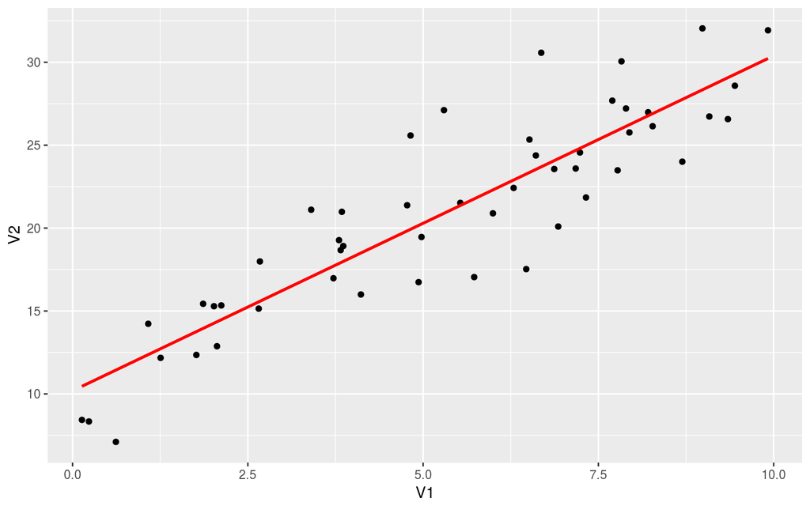

Linear fit by ordinary least squares. If gradient descent is any good, it should find a line close to the red line.

```r
library(tibble)
library(ggplot2)
library(viridis)

set.seed(1)

#function to generate linearly related training data with noise
generate.data = function(N, slope, intercept, mean, sd){
  # randomly pick N x-values uniformly distributed from 1 to 10
  X = matrix(runif(n=N, min=0, max=10))

  # generate y-values for each x, with Gaussian noise
  Y = matrix((intercept+slope*X) + rnorm(n=N, mean = mean, sd = sd))

  return(cbind(X,Y))
}

data = generate.data(N=50, slope=2, intercept=10, mean=0, sd=3)
N = nrow(data)
A = cbind(rep(1,N), data[,1])
b = data[,2]

(ols.plot = ggplot(data = as_data_frame(data), aes(x=V1, y=V2)) +
            geom_point() +
            geom_smooth(method=lm, se=FALSE, color="red")
)
```

The above gradient descent pseudocode implemented in R:

```r
#returns L2 norm of error
error = function(A,x,b){
  return(norm(t(A) %*% A %*% x - t(A) %*% b, type="2"))
}

#gradient descent function
grad.desc = function(A, b, eps, delta, x){
  grad.desc.data = data_frame(epoch=numeric(), x.old=double(), y.old=double(), x.new=double(), y.new=double(), error.old=double(), error.new=double())

  epoch = 1
  err = error(A,x,b)

  while (err>delta){
    #uncomment below to get live output
    #print(paste("epoch: ", epoch, "; error: ", round(err, digits=6), "x: ", round(x[1], digits=3), ",",round(x[2], digits=3)))

    grad.desc.data[epoch,1] = epoch
    grad.desc.data[epoch,2] = x[1]
    grad.desc.data[epoch,3] = x[2]
    grad.desc.data[epoch,6] = err

    #the actual gradient descent occurs in this line:
    x = x-eps*(t(A) %*% A %*% x - t(A) %*% b)

    grad.desc.data[epoch,4] = x[1]
    grad.desc.data[epoch,5] = x[2]
    err = error(A,x,b)
    grad.desc.data[epoch,7] = err
    epoch = epoch+1
  }
  grad.desc.data$even.odd = ifelse(grad.desc.data$epoch%%2==0, "EVEN", "ODD")
  return(grad.desc.data)
}

grad.desc.data = grad.desc(A, b, eps=.001, delta=.5, x=c(8,0.5))
```

Now some plotting to look closer at what happened:

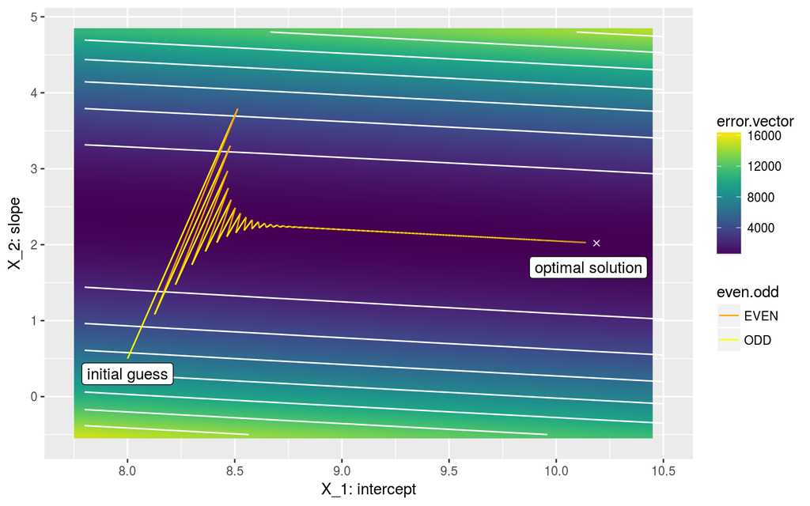

```r
#Set data range for plotting
xmin = round(min(grad.desc.data$x.old), digits=1)-1
xmax = round(max(grad.desc.data$x.old), digits=1)+1
ymin = round(min(grad.desc.data$y.old), digits=1)-1
ymax = round(max(grad.desc.data$y.old), digits=1)+1

xrange = seq(from=xmin, to=xmax, by=0.1)
yrange = seq(from=ymin, to=ymax, by=0.1)

grid = as.matrix(expand.grid(xrange, yrange))
k = dim(grid)[1]

b.broadcast = b %*% t(rep(1, k))

error.vector = diag(t(b.broadcast-A%*%t(grid)) %*% (b.broadcast-A%*%t(grid)))
grid.error = as_data_frame(cbind(grid, error.vector))

lm.fit = lm(b~data[,1])
x.lm = as_data_frame(t(as.matrix(coef(lm.fit))))
names(x.lm) = c("V1","V2")

(error.plot = ggplot() +
        geom_raster(data= grid.error, aes(x=Var1, y=Var2, fill=error.vector), interpolate = TRUE) +
        geom_contour(data= grid.error, aes(x=Var1, y=Var2, z=error.vector), color="white") +
        geom_point(data= x.lm, aes(x=V1, y=V2), shape=4, color="white") +
        geom_segment(data= grad.desc.data, aes(x=x.old, y=y.old, xend=x.new, yend=y.new, color=even.odd)) +
        scale_x_continuous(limits = c(7.75,10.5)) +
        scale_fill_viridis() +
        scale_color_manual(values = c("orange","yellow")) +
        xlab("X_1: intercept") + ylab("X_2: slope") +
        annotate("label",x=8,y=0.3, label="initial guess") +
        annotate("label",x=10.15,y=1.7, label="optimal solution")
)
```

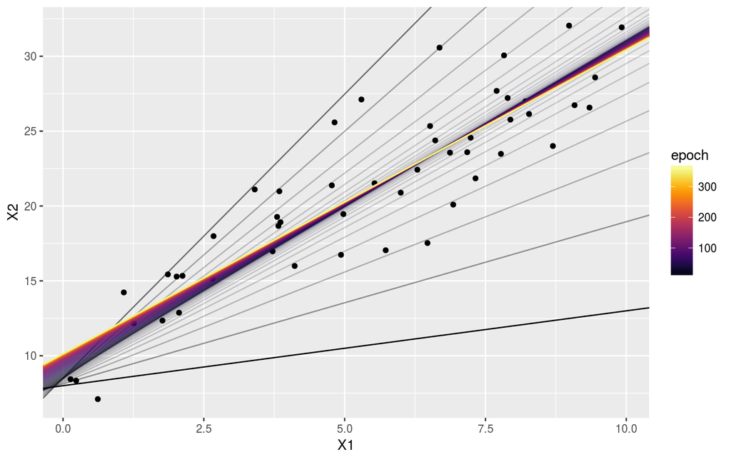

```r
(lm.plot = ggplot() +
            geom_point(data=data.frame(data), aes(x=X1, y=X2)) +
            #geom_abline(slope=2, intercept=10) + #generating line
            #geom_smooth(data=data.frame(data), aes(x=X1, y=X2), method = lm) + #least squares analytical soln
            geom_abline(data=grad.desc.data, aes(intercept=x.old, slope=y.old, color=epoch, alpha=1/epoch)) +
            scale_alpha(guide='none') +
            scale_color_viridis(option="inferno")
)
```

Above is what the line represented by the slope and intercept looks like through iterations of gradient descent. As the algorithm progresses (indicated by the progression of black to yellow), the line gets closer and closer to the optimal line.